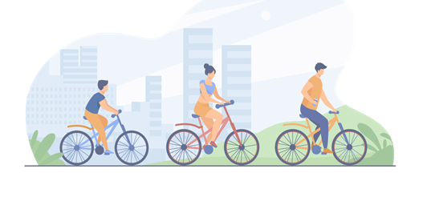

# Modelando el comportamiento de los arriendos de bicicletas en Seúl según la temperatura ambiental.

### Contexto General de los Datos

#### Data Set: Registro de arriendo de bicicletas por hora en la ciudad de Seúl, Corea del Sur, entre 01/12/2017 y 30/11/2018

- Disponibilidad: carpeta public_bikes_2018documentación en https://www.kaggle.com/competitions/seoul-bike-rental-prediction/overview/data-description
- Fuente: Seoul Bike Rental Prediction

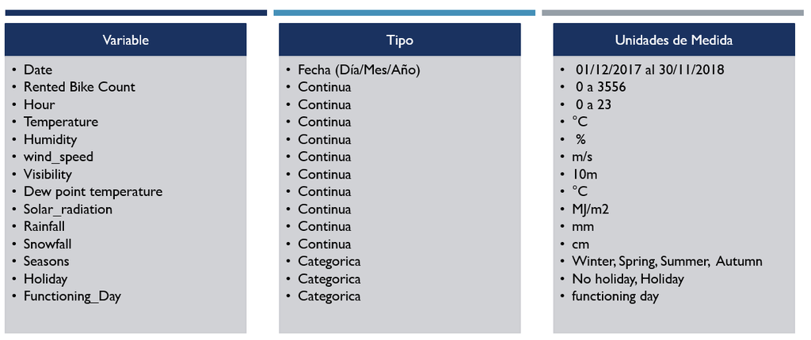

#### Limpieza de datos:

En primera instancia, se cambió el nombre de las variables para que exista un mejor manejo con la BBDD. Además, hizo una revision de cada variable para la limpieza de los valores nulos y duplicados.

Respecto al formato de cada variable, se cambia "date" por DD-MM-AAAA para revisar los parametros de forma individual y la visualización de las variables de manera independiente.

Descripción estadistica de las variables (promedio, min, ax. cuartiles)

Comparación de arriendos según día calendario y dia funcional para realizar cuadro de correlación y eliminar las variables que no aportan al modelo.

En cuanto a la relación entre la fecha y el arriendo nos dimos cuenta de que habían 295 valores cero en arriendo de bicicletas *Rent Bike Count* que corresponden a los días en que no funcionaba el servicio, por lo que se decidió imputar esos datos para tener una aproximación de como se hubiese comportado un día de funcionamiento.

Se realizaron visualizaciones de las distintas variables del DataSet para identificar de mejor manera lo que los números nos indican.

*Se realizó el mismo tratamiento en el notebook para la base con lo datos imputados*

#### Chequeo de los supuestos:

- Se espera que hayan menos arriendos en los días en que las temperaturas son más bajas.

Se cumple la hipotesis

- Se espera que haya menos arriendos en las horas en que la gente está en su lugar de trabajo o estudio y que aumente en las horas en que se desplazan desde o hacia sus viviendas.

Se cumple la hipotesis

Se espera que haya menos arriendos los días en que hay lluvia o nieve.

Con la información disponible, no es sufciente para predecir el arriendo de las bicicletas.

Se espera que haya más arriendos en las estaciones de primavera y verano.

### Importando Librerias

```python
import numpy as np
import matplotlib.pyplot as plt
import pandas as pd
import seaborn as sns

import statsmodels as sms
import statsmodels.formula as smf
```

### Importando y leyendo base de Datos SeoulBikeData

```python
# Leer el dataset con datos imputados

bikedata = pd.read_excel("SeoulBikeData_DatosImputados.xlsx")
```

```python
#Renombrando Variables para su evaluación y Proceso

bikedata=bikedata.rename({'Rented Bike Count': 'Rented_Bike_Count','Temperature(°C)': 'Temperature' ,'Humidity(%)':'Humidity', 'Wind speed (m/s)': 'wind_speed',
                 'Visibility (10m)':'Visibility', 'Dew point temperature(°C)':'Dew_point_temperature',
                 'Solar Radiation (MJ/m2)':'Solar_radiation', 'Rainfall(mm)':'Rainfall', 'Snowfall (cm)': 'Snowfall',
                 'Functioning Day': 'Functioning_Day' },axis=1)
```

### Cambiando Fecha a formato 'Datetime' y creando variables de día, mes, año para evaluación de los arriendos de bicicletas

```python
#trasformar fecha a formato 'Datetime'

bikedata['Date']=pd.to_datetime(bikedata['Date'],infer_datetime_format= True)
bikedata['Month']=bikedata.Date.dt.month_name().str[:3]
bikedata['Year']= bikedata.Date.dt.year
bikedata['Weekday']= bikedata.Date.dt.weekday
bikedata.Weekday= bikedata.Weekday.map({0:'Monday', 1:'Tuesday',2:'Wednesday', 3:'Thursday', 4:'Fryday', 5: 'Saturday', 6:'Sunday'})
bikedata['Weekday']= pd.Categorical(bikedata['Weekday'],
                     categories= ['Monday','Tuesday','Wednesday','Thursday', 'Fryday','Saturday', 'Sunday'] , ordered=True)
```

```python
#Evaluación de Esatdísticos de las variables

bikedata.describe().transpose()
```

|  | count | mean | std | min | 25% | 50% | 75% | max |
| --- | --- | --- | --- | --- | --- | --- | --- | --- |
| Rented_Bike_Count | 8760.0 | 736.804623 | 642.278158 | 2.0 | 218.00 | 556.0 | 1096.00 | 3556.0 |
| Hour | 8760.0 | 11.500000 | 6.922582 | 0.0 | 5.75 | 11.5 | 17.25 | 23.0 |
| Temperature | 8760.0 | 117.488813 | 118.879484 | -178.0 | 18.00 | 115.0 | 217.00 | 394.0 |
| Humidity | 8760.0 | 58.226256 | 20.362413 | 0.0 | 42.00 | 57.0 | 74.00 | 98.0 |
| wind_speed | 8760.0 | 15.646347 | 10.878694 | 0.0 | 7.00 | 14.0 | 23.00 | 74.0 |
| Visibility | 8760.0 | 1436.825799 | 608.298712 | 27.0 | 940.00 | 1698.0 | 2000.00 | 2000.0 |
| Dew_point_temperature | 8760.0 | 36.808333 | 124.048701 | -306.0 | -34.00 | 28.0 | 137.00 | 272.0 |
| Solar_radiation | 8760.0 | 52.008333 | 84.138884 | 0.0 | 0.00 | 1.0 | 78.00 | 352.0 |
| Rainfall | 8760.0 | 0.886872 | 7.859516 | 0.0 | 0.00 | 0.0 | 0.00 | 295.0 |
| Snowfall | 8760.0 | 0.609932 | 3.882392 | 0.0 | 0.00 | 0.0 | 0.00 | 88.0 |
| Year | 8760.0 | 2017.915068 | 0.278796 | 2017.0 | 2018.00 | 2018.0 | 2018.00 | 2018.0 |

### Correlacion de las variables del Dataset y el Arriendo de Bicicletas

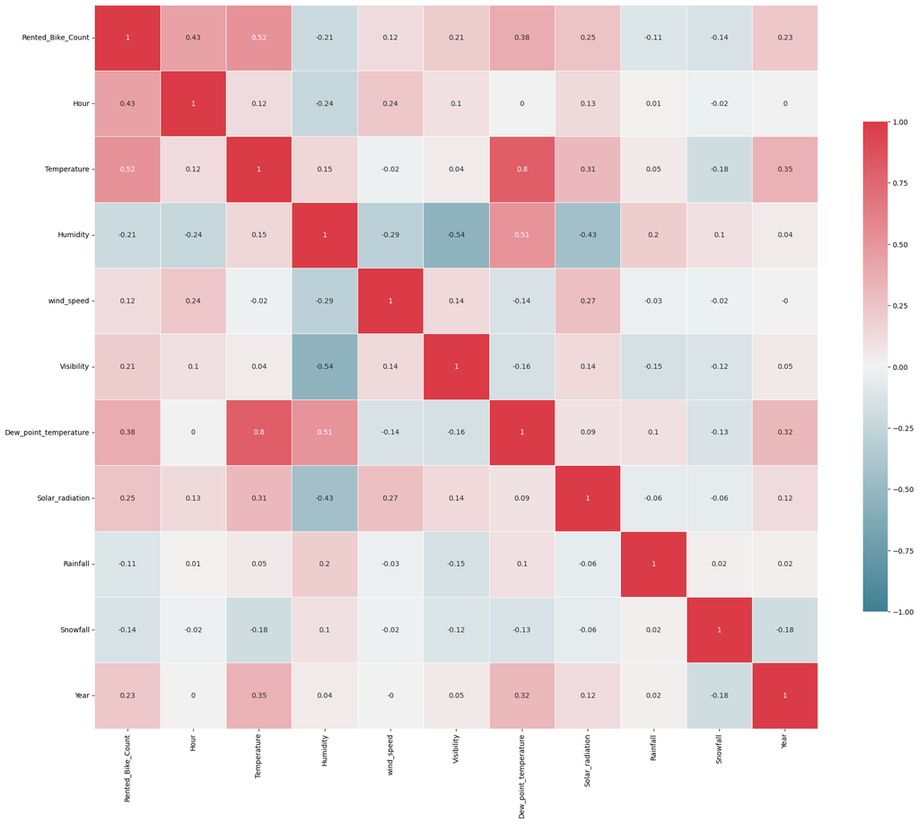

```python
# Generando matriz de correlacion de datos
corr = bikedata.corr().round(2)
# Visualizando la matriz de correlacion
f, ax = plt.subplots(figsize=(20, 20))
cmap = sns.diverging_palette(220, 10, as_cmap=True)
sns.heatmap(corr, cmap=cmap, vmin=-1, vmax=1, center=0,
            square=True, linewidths=.5, cbar_kws={"shrink": .5}, annot=True)

plt.tight_layout()
```

[output not shown]

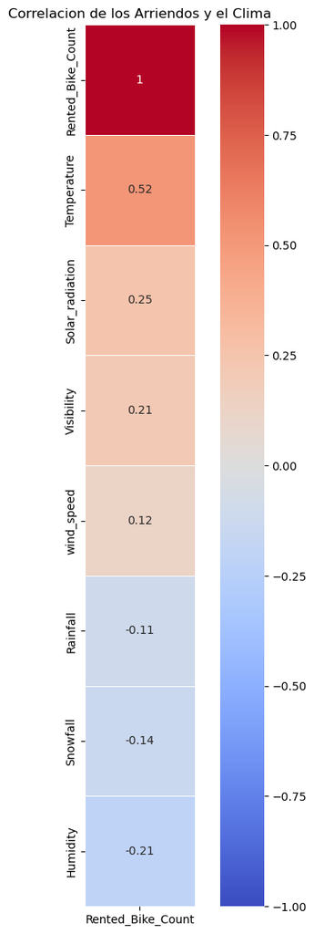

```python
# Visualizando la correlacion de las variables del clima y el arriendo de Bicicletas

f, ax = plt.subplots(figsize=(8, 14))

corr= bikedata[['Temperature', 'wind_speed','Humidity','Solar_radiation','Rainfall','Visibility','Snowfall','Rented_Bike_Count']].corr()
sns.heatmap(data=corr[['Rented_Bike_Count']].sort_values(by= 'Rented_Bike_Count', ascending= False), vmin=-1, vmax=1, center=0,
            cmap='coolwarm', annot= True, square=True, linewidths = .5)
plt.title('Correlacion de los Arriendos y el Clima')
plt.savefig('Correlacion.png',dpi=300)
plt.show
```

### Eliminando las variables que no aportan al modelo

```python
bikedata_final= bikedata.drop(columns=['Functioning_Day','Dew_point_temperature' ], axis=1)
bikedata_final.head()
```

|  | Date | Rented_Bike_Count | Hour | Temperature | Humidity | wind_speed | Visibility | Solar_radiation | Rainfall | Snowfall | Seasons | Holiday | Month | Year | Weekday |
| --- | --- | --- | --- | --- | --- | --- | --- | --- | --- | --- | --- | --- | --- | --- | --- |
| 0 | 2017-12-01 | 254.0 | 0 | -52 | 37 | 22 | 2000 | 0 | 0 | 0 | Winter | No Holiday | Dec | 2017 | Fryday |
| 1 | 2017-12-01 | 204.0 | 1 | -55 | 38 | 8 | 2000 | 0 | 0 | 0 | Winter | No Holiday | Dec | 2017 | Fryday |
| 2 | 2017-12-01 | 173.0 | 2 | -6 | 39 | 1 | 2000 | 0 | 0 | 0 | Winter | No Holiday | Dec | 2017 | Fryday |
| 3 | 2017-12-01 | 107.0 | 3 | -62 | 40 | 9 | 2000 | 0 | 0 | 0 | Winter | No Holiday | Dec | 2017 | Fryday |
| 4 | 2017-12-01 | 78.0 | 4 | -6 | 36 | 23 | 2000 | 0 | 0 | 0 | Winter | No Holiday | Dec | 2017 | Fryday |

## Procesando Datos

```python
import statsmodels.api as sm
import statsmodels.formula.api as smf
```

```python
bikedata_final.columns
```

```
Index(['Date', 'Rented_Bike_Count', 'Hour', 'Temperature', 'Humidity',
       'wind_speed', 'Visibility', 'Solar_radiation', 'Rainfall', 'Snowfall',
       'Seasons', 'Holiday', 'Month', 'Year', 'Weekday'],
      dtype='object')
```

```python
mod1 = smf.ols(formula='Rented_Bike_Count ~ Hour + Temperature + Humidity + wind_speed + Visibility + Solar_radiation + Rainfall + Snowfall+ Seasons + Holiday + Month  + Year + Weekday',data=bikedata_final)
res1 = mod1.fit()
print(res1.summary())
```

```
                            OLS Regression Results
==============================================================================
Dep. Variable:      Rented_Bike_Count   R-squared:                       0.561
Model:                            OLS   Adj. R-squared:                  0.559
Method:                 Least Squares   F-statistic:                     428.7
Date:                Mon, 17 Oct 2022   Prob (F-statistic):               0.00
Time:                        22:13:07   Log-Likelihood:                -65460.
No. Observations:                8760   AIC:                         1.310e+05
Df Residuals:                    8733   BIC:                         1.312e+05
Df Model:                          26
Covariance Type:            nonrobust
=========================================================================================
                            coef    std err          t      P>|t|      [0.025      0.975]
-----------------------------------------------------------------------------------------
Intercept                -0.0268      0.007     -4.014      0.000      -0.040      -0.014
Seasons[T.Spring]       -84.2823     14.408     -5.850      0.000    -112.525     -56.040
Seasons[T.Summer]       123.0428     10.646     11.558      0.000     102.175     143.911
Seasons[T.Winter]      -387.6628     12.020    -32.251      0.000    -411.225    -364.100
Holiday[T.No Holiday]   125.9474     21.542      5.847      0.000      83.719     168.175
Month[T.Aug]           -147.4912     14.087    -10.470      0.000    -175.105    -119.878
Month[T.Dec]            -54.4011     13.468     -4.039      0.000     -80.801     -28.001
Month[T.Feb]           -169.0396     13.921    -12.143      0.000    -196.329    -141.751
Month[T.Jan]           -164.2221     13.844    -11.863      0.000    -191.359    -137.085
Month[T.Jul]              3.0302     13.651      0.222      0.824     -23.729      29.790
Month[T.Jun]            267.5038     13.473     19.856      0.000     241.094     293.913
Month[T.Mar]           -163.4493     22.665     -7.212      0.000    -207.877    -119.021
Month[T.May]            259.0352     22.816     11.353      0.000     214.310     303.761
Month[T.Nov]            -60.0770     15.290     -3.929      0.000     -90.049     -30.105
Month[T.Oct]            185.1585     14.067     13.162      0.000     157.583     212.734
Month[T.Sep]            223.7941     16.271     13.755      0.000     191.900     255.688
Weekday[T.Tuesday]       32.3146     17.101      1.890      0.059      -1.208      65.837
Weekday[T.Wednesday]     47.1718     17.124      2.755      0.006      13.604      80.740
Weekday[T.Thursday]      16.2151     17.119      0.947      0.344     -17.342      49.773
Weekday[T.Fryday]        41.1972     17.025      2.420      0.016       7.825      74.569
Weekday[T.Saturday]     -16.5876     17.123     -0.969      0.333     -50.153      16.978
Weekday[T.Sunday]       -81.1416     17.090     -4.748      0.000    -114.643     -47.640
Hour                     31.7714      0.708     44.873      0.000      30.384      33.159
Temperature               1.1385      0.078     14.520      0.000       0.985       1.292
Humidity                 -8.8658      0.374    -23.716      0.000      -9.599      -8.133
wind_speed                1.7452      0.460      3.796      0.000       0.844       2.647
Visibility               -0.0126      0.011     -1.160      0.246      -0.034       0.009
Solar_radiation          -0.5282      0.069     -7.606      0.000      -0.664      -0.392
Rainfall                 -7.9131      0.595    -13.291      0.000      -9.080      -6.746
Snowfall                  3.0610      1.233      2.482      0.013       0.644       5.478
Year                      0.3579      0.023     15.679      0.000       0.313       0.403
==============================================================================
Omnibus:                     1084.134   Durbin-Watson:                   0.597
Prob(Omnibus):                  0.000   Jarque-Bera (JB):             1868.593
Skew:                           0.836   Prob(JB):                         0.00
Kurtosis:                       4.523   Cond. No.                     1.58e+17
==============================================================================

Notes:
[1] Standard Errors assume that the covariance matrix of the errors is correctly specified.
[2] The smallest eigenvalue is 2.21e-24. This might indicate that there are
strong multicollinearity problems or that the design matrix is singular.
```

```python
#Eliminando Variables con Pvalue mayor a 0.05 , se eliminina visibility

mod2 = smf.ols(formula='Rented_Bike_Count ~ Hour + Temperature + Humidity + wind_speed + Solar_radiation + Rainfall + Snowfall+ Seasons + Holiday + Month  + Year + Weekday',data=bikedata_final)
res2 = mod2.fit()
print(res2.summary())
```

```
                            OLS Regression Results
==============================================================================
Dep. Variable:      Rented_Bike_Count   R-squared:                       0.561
Model:                            OLS   Adj. R-squared:                  0.559
Method:                 Least Squares   F-statistic:                     445.8
Date:                Mon, 17 Oct 2022   Prob (F-statistic):               0.00
Time:                        22:13:07   Log-Likelihood:                -65461.
No. Observations:                8760   AIC:                         1.310e+05
Df Residuals:                    8734   BIC:                         1.312e+05
Df Model:                          25
Covariance Type:            nonrobust
=========================================================================================
                            coef    std err          t      P>|t|      [0.025      0.975]
-----------------------------------------------------------------------------------------
Intercept                -0.0262      0.007     -3.935      0.000      -0.039      -0.013
Seasons[T.Spring]       -81.3300     14.181     -5.735      0.000    -109.129     -53.531
Seasons[T.Summer]       119.4439     10.184     11.729      0.000      99.481     139.406
Seasons[T.Winter]      -383.0316     11.338    -33.783      0.000    -405.256    -360.807
Holiday[T.No Holiday]   125.5320     21.540      5.828      0.000      83.309     167.755
Month[T.Aug]           -151.6067     13.633    -11.121      0.000    -178.330    -124.883
Month[T.Dec]            -53.1639     13.426     -3.960      0.000     -79.482     -26.846
Month[T.Feb]           -167.9037     13.887    -12.091      0.000    -195.126    -140.682
Month[T.Jan]           -161.9640     13.706    -11.817      0.000    -188.831    -135.097
Month[T.Jul]              0.4086     13.463      0.030      0.976     -25.982      26.799
Month[T.Jun]            270.6420     13.198     20.506      0.000     244.770     296.514
Month[T.Mar]           -161.3236     22.591     -7.141      0.000    -205.607    -117.040
Month[T.May]            256.8749     22.741     11.296      0.000     212.298     301.452
Month[T.Nov]            -54.9259     14.631     -3.754      0.000     -83.606     -26.246
Month[T.Oct]            182.5853     13.891     13.144      0.000     155.355     209.816
Month[T.Sep]            217.2320     15.255     14.240      0.000     187.328     247.136
Weekday[T.Tuesday]       31.4961     17.087      1.843      0.065      -1.998      64.990
Weekday[T.Wednesday]     45.9649     17.093      2.689      0.007      12.458      79.471
Weekday[T.Thursday]      15.4497     17.107      0.903      0.366     -18.084      48.983
Weekday[T.Fryday]        41.1600     17.025      2.418      0.016       7.787      74.533
Weekday[T.Saturday]     -16.5721     17.123     -0.968      0.333     -50.138      16.994
Weekday[T.Sunday]       -81.1016     17.091     -4.745      0.000    -114.603     -47.600
Hour                     31.7983      0.708     44.934      0.000      30.411      33.185
Temperature               1.1587      0.076     15.159      0.000       1.009       1.309
Humidity                 -8.5948      0.292    -29.452      0.000      -9.167      -8.023
wind_speed                1.7143      0.459      3.735      0.000       0.814       2.614
Solar_radiation          -0.5114      0.068     -7.529      0.000      -0.645      -0.378
Rainfall                 -7.8721      0.594    -13.245      0.000      -9.037      -6.707
Snowfall                  3.0840      1.233      2.501      0.012       0.667       5.501
Year                      0.3396      0.016     20.606      0.000       0.307       0.372
==============================================================================
Omnibus:                     1085.017   Durbin-Watson:                   0.598
Prob(Omnibus):                  0.000   Jarque-Bera (JB):             1868.959
Skew:                           0.837   Prob(JB):                         0.00
Kurtosis:                       4.522   Cond. No.                     5.04e+17
==============================================================================

Notes:
[1] Standard Errors assume that the covariance matrix of the errors is correctly specified.
[2] The smallest eigenvalue is 1.41e-25. This might indicate that there are
strong multicollinearity problems or that the design matrix is singular.
```

Al emliminar la variable Visibility mejoran los indicadores

```python
#Eliminando Variables con Pvalue mayor a 0.05
# Valiables : Month, Weekday, Visibility

mod3= smf.ols(formula='Rented_Bike_Count ~ Hour + Temperature + Humidity + wind_speed + Solar_radiation + Rainfall + Snowfall+ Seasons + Holiday + Year',data=bikedata_final)
res3 = mod3.fit()
print(res3.summary())
```

```
                            OLS Regression Results
==============================================================================
Dep. Variable:      Rented_Bike_Count   R-squared:                       0.513
Model:                            OLS   Adj. R-squared:                  0.513
Method:                 Least Squares   F-statistic:                     768.7
Date:                Mon, 17 Oct 2022   Prob (F-statistic):               0.00
Time:                        22:13:07   Log-Likelihood:                -65909.
No. Observations:                8760   AIC:                         1.318e+05
Df Residuals:                    8747   BIC:                         1.319e+05
Df Model:                          12
Covariance Type:            nonrobust
=========================================================================================
                            coef    std err          t      P>|t|      [0.025      0.975]
-----------------------------------------------------------------------------------------
Intercept              2.042e+05   4.15e+04      4.918      0.000    1.23e+05    2.86e+05
Seasons[T.Spring]      -161.4361     13.731    -11.757      0.000    -188.351    -134.521
Seasons[T.Summer]        -3.1112     15.783     -0.197      0.844     -34.049      27.826
Seasons[T.Winter]      -599.0621     19.194    -31.211      0.000    -636.686    -561.438
Holiday[T.No Holiday]    86.7601     22.387      3.875      0.000      42.876     130.644
Hour                     31.2579      0.741     42.164      0.000      29.805      32.711
Temperature               1.5117      0.071     21.436      0.000       1.373       1.650
Humidity                 -8.1277      0.304    -26.750      0.000      -8.723      -7.532
wind_speed                1.7069      0.480      3.553      0.000       0.765       2.649
Solar_radiation          -0.4191      0.071     -5.898      0.000      -0.558      -0.280
Rainfall                 -7.5813      0.624    -12.148      0.000      -8.805      -6.358
Snowfall                  1.9841      1.289      1.539      0.124      -0.544       4.512
Year                   -100.7953     20.573     -4.900      0.000    -141.122     -60.468
==============================================================================
Omnibus:                     1421.247   Durbin-Watson:                   0.554
Prob(Omnibus):                  0.000   Jarque-Bera (JB):             2750.462
Skew:                           1.002   Prob(JB):                         0.00
Kurtosis:                       4.876   Cond. No.                     1.75e+07
==============================================================================

Notes:
[1] Standard Errors assume that the covariance matrix of the errors is correctly specified.
[2] The condition number is large, 1.75e+07. This might indicate that there are
strong multicollinearity or other numerical problems.
```

Al emilinar mes y día de la semana, empeoran los indicadores

```python
#Eliminando Variables con Pvalue mayor a 0.05
# Valiables : Month, Weekday, Visibility, Snowfall

mod4= smf.ols(formula='Rented_Bike_Count ~ Hour + Temperature + Humidity + wind_speed + Solar_radiation + Rainfall + Seasons + Holiday + Year',data=bikedata_final)
res4 = mod4.fit()
print(res4.summary())
```

```
                            OLS Regression Results
==============================================================================
Dep. Variable:      Rented_Bike_Count   R-squared:                       0.513
Model:                            OLS   Adj. R-squared:                  0.513
Method:                 Least Squares   F-statistic:                     838.2
Date:                Mon, 17 Oct 2022   Prob (F-statistic):               0.00
Time:                        22:13:07   Log-Likelihood:                -65910.
No. Observations:                8760   AIC:                         1.318e+05
Df Residuals:                    8748   BIC:                         1.319e+05
Df Model:                          11
Covariance Type:            nonrobust
=========================================================================================
                            coef    std err          t      P>|t|      [0.025      0.975]
-----------------------------------------------------------------------------------------
Intercept              2.089e+05   4.14e+04      5.044      0.000    1.28e+05     2.9e+05
Seasons[T.Spring]      -162.5118     13.714    -11.850      0.000    -189.394    -135.629
Seasons[T.Summer]        -3.9329     15.775     -0.249      0.803     -34.855      26.989
Seasons[T.Winter]      -596.7929     19.139    -31.183      0.000    -634.309    -559.277
Holiday[T.No Holiday]    87.8421     22.378      3.925      0.000      43.976     131.708
Hour                     31.2845      0.741     42.208      0.000      29.832      32.737
Temperature               1.5052      0.070     21.380      0.000       1.367       1.643
Humidity                 -8.0513      0.300    -26.857      0.000      -8.639      -7.464
wind_speed                1.7037      0.481      3.546      0.000       0.762       2.646
Solar_radiation          -0.4105      0.071     -5.795      0.000      -0.549      -0.272
Rainfall                 -7.5790      0.624    -12.143      0.000      -8.802      -6.356
Year                   -103.1221     20.518     -5.026      0.000    -143.343     -62.901
==============================================================================
Omnibus:                     1421.242   Durbin-Watson:                   0.553
Prob(Omnibus):                  0.000   Jarque-Bera (JB):             2748.370
Skew:                           1.002   Prob(JB):                         0.00
Kurtosis:                       4.874   Cond. No.                     1.75e+07
==============================================================================

Notes:
[1] Standard Errors assume that the covariance matrix of the errors is correctly specified.
[2] The condition number is large, 1.75e+07. This might indicate that there are
strong multicollinearity or other numerical problems.
```

al eliminiar Snowfall no mejora el desempeño.

```python
#Eliminando Variables con Pvalue mayor a 0.05
# Valiables : Month, Weekday,Year, Visibility, wind_speed

mod5= smf.ols(formula='Rented_Bike_Count ~ Hour + Temperature + Humidity + Solar_radiation + Rainfall + Snowfall+ Holiday',data=bikedata_final)
res5 = mod5.fit()
print(res5.summary())
```

```
                            OLS Regression Results
==============================================================================
Dep. Variable:      Rented_Bike_Count   R-squared:                       0.455
Model:                            OLS   Adj. R-squared:                  0.455
Method:                 Least Squares   F-statistic:                     1045.
Date:                Mon, 17 Oct 2022   Prob (F-statistic):               0.00
Time:                        22:13:08   Log-Likelihood:                -66403.
No. Observations:                8760   AIC:                         1.328e+05
Df Residuals:                    8752   BIC:                         1.329e+05
Df Model:                           7
Covariance Type:            nonrobust
=========================================================================================
                            coef    std err          t      P>|t|      [0.025      0.975]
-----------------------------------------------------------------------------------------
Intercept               329.4480     30.995     10.629      0.000     268.691     390.205
Holiday[T.No Holiday]   134.4697     23.463      5.731      0.000      88.477     180.462
Hour                     30.3305      0.766     39.589      0.000      28.829      31.832
Temperature               2.8083      0.049     57.283      0.000       2.712       2.904
Humidity                 -6.4149      0.310    -20.709      0.000      -7.022      -5.808
Solar_radiation          -0.3297      0.074     -4.485      0.000      -0.474      -0.186
Rainfall                 -7.9024      0.660    -11.982      0.000      -9.195      -6.610
Snowfall                 -2.5529      1.343     -1.901      0.057      -5.185       0.079
==============================================================================
Omnibus:                     1510.442   Durbin-Watson:                   0.599
Prob(Omnibus):                  0.000   Jarque-Bera (JB):             3036.552
Skew:                           1.042   Prob(JB):                         0.00
Kurtosis:                       4.995   Cond. No.                     1.30e+03
==============================================================================

Notes:
[1] Standard Errors assume that the covariance matrix of the errors is correctly specified.
[2] The condition number is large, 1.3e+03. This might indicate that there are
strong multicollinearity or other numerical problems.
```

Al eliminar nuevos parametros el desempeño empeora más.

## Evaluando los parametros

```python
# Extraemos los parámetros del modelo para luego hacemos un gráfico de los datos y el ajuste

#El segundo fue el modelo con mejor desempeño.

params2 = res2.params
print(params2)
```

```
Intercept                 -0.026177
Seasons[T.Spring]        -81.329951
Seasons[T.Summer]        119.443946
Seasons[T.Winter]       -383.031579
Holiday[T.No Holiday]    125.532004
Month[T.Aug]            -151.606661
Month[T.Dec]             -53.163902
Month[T.Feb]            -167.903677
Month[T.Jan]            -161.964001
Month[T.Jul]               0.408577
Month[T.Jun]             270.642031
Month[T.Mar]            -161.323573
Month[T.May]             256.874856
Month[T.Nov]             -54.925945
Month[T.Oct]             182.585348
Month[T.Sep]             217.232004
Weekday[T.Tuesday]        31.496110
Weekday[T.Wednesday]      45.964888
Weekday[T.Thursday]       15.449741
Weekday[T.Fryday]         41.159981
Weekday[T.Saturday]      -16.572149
Weekday[T.Sunday]        -81.101601
Hour                      31.798258
Temperature                1.158707
Humidity                  -8.594776
wind_speed                 1.714267
Solar_radiation           -0.511389
Rainfall                  -7.872082
Snowfall                   3.084025
Year                       0.339617
dtype: float64
```

```python
from statsmodels.compat import lzip
import statsmodels.formula.api as smf
import statsmodels.stats.api as sms
import matplotlib.pyplot as plt
```

## Evaluando los Modelos

#### Testeando la Linealidad

#### Harvey-Collier multiplier test for Null hypothesis

#### that the linear specification is correct:

```python
# Estimar normalidad de los residuos del segundo Modelo
# Jarque_Bera test
name = ["Jarque-Bera", "Chi^2 two-tail prob.", "Skew", "Kurtosis"]
test = sms.jarque_bera(res2.resid)
lzip(name, test)
```

```
[('Jarque-Bera', 1868.9585702960173),
 ('Chi^2 two-tail prob.', 0.0),
 ('Skew', 0.837260141226303),
 ('Kurtosis', 4.521977747150731)]
```

```python
# Omni test
name = ["Chi^2", "Two-tail probability"]
test = sms.omni_normtest(res2.resid)
lzip(name, test)
```

```
[('Chi^2', 1085.0169241197225),
 ('Two-tail probability', 2.4635906183894763e-236)]
```

#### Detección de Heteroscedasticidad:

```python
# Breusch-Pagan test
name = ["Lagrange multiplier statistic", "p-value", "f-value", "f p-value"]
test = sms.het_breuschpagan(res2.resid, res2.model.exog)
lzip(name, test)
```

```
[('Lagrange multiplier statistic', 996.9103941598524),
 ('p-value', 3.890839581879941e-191),
 ('f-value', 44.863660344932235),
 ('f p-value', 5.667804427761535e-207)]
```

```python
#Goldfeld-Quandttest
name = ["F statistic", "p-value"]
test = sms.het_goldfeldquandt(res2.resid, res2.model.exog)
lzip(name, test)
```

```
[('F statistic', 1.8840880037547483), ('p-value', 7.524566116066344e-96)]
```

```python
# base code
import numpy as np
import seaborn as sns
import statsmodels
from statsmodels.tools.tools import maybe_unwrap_results
from statsmodels.graphics.gofplots import ProbPlot
from statsmodels.stats.outliers_influence import variance_inflation_factor
import matplotlib.pyplot as plt
from typing import Type

style_talk = 'seaborn-talk'    #refer to plt.style.available

class Linear_Reg_Diagnostic():
    """
    Diagnostic plots to identify potential problems in a linear regression fit.
    Mainly,
        a. non-linearity of data
        b. Correlation of error terms
        c. non-constant variance
        d. outliers
        e. high-leverage points
        f. collinearity

    Author:
        Prajwal Kafle (p33ajkafle@gmail.com, where 3 = r)
        Does not come with any sort of warranty.
        Please test the code one your end before using.
    """

    def __init__(self,
                 results: Type[statsmodels.regression.linear_model.RegressionResultsWrapper]) -> None:
        """
        For a linear regression model, generates following diagnostic plots:

        a. residual
        b. qq
        c. scale location and
        d. leverage

        and a table

        e. vif

        Args:
            results (Type[statsmodels.regression.linear_model.RegressionResultsWrapper]):
                must be instance of statsmodels.regression.linear_model object

        Raises:
            TypeError: if instance does not belong to above object

        Example:
        >>> import numpy as np
        >>> import pandas as pd
        >>> import statsmodels.formula.api as smf
        >>> x = np.linspace(-np.pi, np.pi, 100)
        >>> y = 3*x + 8 + np.random.normal(0,1, 100)
        >>> df = pd.DataFrame({'x':x, 'y':y})
        >>> res = smf.ols(formula= "y ~ x", data=df).fit()
        >>> cls = Linear_Reg_Diagnostic(res)
        >>> cls(plot_context="seaborn-paper")

        In case you do not need all plots you can also independently make an individual plot/table
        in following ways

        >>> cls = Linear_Reg_Diagnostic(res)
        >>> cls.residual_plot()
        >>> cls.qq_plot()
        >>> cls.scale_location_plot()
        >>> cls.leverage_plot()
        >>> cls.vif_table()
        """

        if isinstance(results, statsmodels.regression.linear_model.RegressionResultsWrapper) is False:
            raise TypeError("result must be instance of statsmodels.regression.linear_model.RegressionResultsWrapper object")

        self.results = maybe_unwrap_results(results)

        self.y_true = self.results.model.endog
        self.y_predict = self.results.fittedvalues
        self.xvar = self.results.model.exog
        self.xvar_names = self.results.model.exog_names

        self.residual = np.array(self.results.resid)
        influence = self.results.get_influence()
        self.residual_norm = influence.resid_studentized_internal
        self.leverage = influence.hat_matrix_diag
        self.cooks_distance = influence.cooks_distance[0]
        self.nparams = len(self.results.params)

    def __call__(self, plot_context='seaborn-paper'):
        # print(plt.style.available)
        with plt.style.context(plot_context):
            fig, ax = plt.subplots(nrows=2, ncols=2, figsize=(10,10))
            self.residual_plot(ax=ax[0,0])
            self.qq_plot(ax=ax[0,1])
            self.scale_location_plot(ax=ax[1,0])
            self.leverage_plot(ax=ax[1,1])
            plt.show()

        self.vif_table()
        return fig, ax


    def residual_plot(self, ax=None):
        """
        Residual vs Fitted Plot

        Graphical tool to identify non-linearity.
        (Roughly) Horizontal red line is an indicator that the residual has a linear pattern
        """
        if ax is None:
            fig, ax = plt.subplots()

        sns.residplot(
            x=self.y_predict,
            y=self.residual,
            lowess=True,
            scatter_kws={'alpha': 0.5},
            line_kws={'color': 'red', 'lw': 1, 'alpha': 0.8},
            ax=ax)

        # annotations
        residual_abs = np.abs(self.residual)
        abs_resid = np.flip(np.sort(residual_abs))
        abs_resid_top_3 = abs_resid[:3]
        for i, _ in enumerate(abs_resid_top_3):
            ax.annotate(
                i,
                xy=(self.y_predict[i], self.residual[i]),
                color='C3')

        ax.set_title('Residuals vs Fitted', fontweight="bold")
        ax.set_xlabel('Fitted values')
        ax.set_ylabel('Residuals')
        return ax

    def qq_plot(self, ax=None):
        """
        Standarized Residual vs Theoretical Quantile plot

        Used to visually check if residuals are normally distributed.
        Points spread along the diagonal line will suggest so.
        """
        if ax is None:
            fig, ax = plt.subplots()

        QQ = ProbPlot(self.residual_norm)
        QQ.qqplot(line='45', alpha=0.5, lw=1, ax=ax)

        # annotations
        abs_norm_resid = np.flip(np.argsort(np.abs(self.residual_norm)), 0)
        abs_norm_resid_top_3 = abs_norm_resid[:3]
        for r, i in enumerate(abs_norm_resid_top_3):
            ax.annotate(
                i,
                xy=(np.flip(QQ.theoretical_quantiles, 0)[r], self.residual_norm[i]),
                ha='right', color='C3')

        ax.set_title('Normal Q-Q', fontweight="bold")
        ax.set_xlabel('Theoretical Quantiles')
        ax.set_ylabel('Standardized Residuals')
        return ax

    def scale_location_plot(self, ax=None):
        """
        Sqrt(Standarized Residual) vs Fitted values plot

        Used to check homoscedasticity of the residuals.
        Horizontal line will suggest so.
        """
        if ax is None:
            fig, ax = plt.subplots()

        residual_norm_abs_sqrt = np.sqrt(np.abs(self.residual_norm))

        ax.scatter(self.y_predict, residual_norm_abs_sqrt, alpha=0.5);
        sns.regplot(
            x=self.y_predict,
            y=residual_norm_abs_sqrt,
            scatter=False, ci=False,
            lowess=True,
            line_kws={'color': 'red', 'lw': 1, 'alpha': 0.8},
            ax=ax)

        # annotations
        abs_sq_norm_resid = np.flip(np.argsort(residual_norm_abs_sqrt), 0)
        abs_sq_norm_resid_top_3 = abs_sq_norm_resid[:3]
        for i in abs_sq_norm_resid_top_3:
            ax.annotate(
                i,
                xy=(self.y_predict[i], residual_norm_abs_sqrt[i]),
                color='C3')
        ax.set_title('Scale-Location', fontweight="bold")
        ax.set_xlabel('Fitted values')
        ax.set_ylabel(r'$\sqrt{|\mathrm{Standardized\ Residuals}|}$');
        return ax

    def leverage_plot(self, ax=None):
        """
        Residual vs Leverage plot

        Points falling outside Cook's distance curves are considered observation that can sway the fit
        aka are influential.
        Good to have none outside the curves.
        """
        if ax is None:
            fig, ax = plt.subplots()

        ax.scatter(
            self.leverage,
            self.residual_norm,
            alpha=0.5);

        sns.regplot(
            x=self.leverage,
            y=self.residual_norm,
            scatter=False,
            ci=False,
            lowess=True,
            line_kws={'color': 'red', 'lw': 1, 'alpha': 0.8},
            ax=ax)

        # annotations
        leverage_top_3 = np.flip(np.argsort(self.cooks_distance), 0)[:3]
        for i in leverage_top_3:
            ax.annotate(
                i,
                xy=(self.leverage[i], self.residual_norm[i]),
                color = 'C3')

        xtemp, ytemp = self.__cooks_dist_line(0.5) # 0.5 line
        ax.plot(xtemp, ytemp, label="Cook's distance", lw=1, ls='--', color='red')
        xtemp, ytemp = self.__cooks_dist_line(1) # 1 line
        ax.plot(xtemp, ytemp, lw=1, ls='--', color='red')

        ax.set_xlim(0, max(self.leverage)+0.01)
        ax.set_title('Residuals vs Leverage', fontweight="bold")
        ax.set_xlabel('Leverage')
        ax.set_ylabel('Standardized Residuals')
        ax.legend(loc='upper right')
        return ax

    def vif_table(self):
        """
        VIF table

        VIF, the variance inflation factor, is a measure of multicollinearity.
        VIF > 5 for a variable indicates that it is highly collinear with the
        other input variables.
        """
        vif_df = pd.DataFrame()
        vif_df["Features"] = self.xvar_names
        vif_df["VIF Factor"] = [variance_inflation_factor(self.xvar, i) for i in range(self.xvar.shape[1])]

        print(vif_df
                .sort_values("VIF Factor")
                .round(2))


    def __cooks_dist_line(self, factor):
        """
        Helper function for plotting Cook's distance curves
        """
        p = self.nparams
        formula = lambda x: np.sqrt((factor * p * (1 - x)) / x)
        x = np.linspace(0.001, max(self.leverage), 50)
        y = formula(x)
        return x, y
```

### Diagnostico Modelo 2

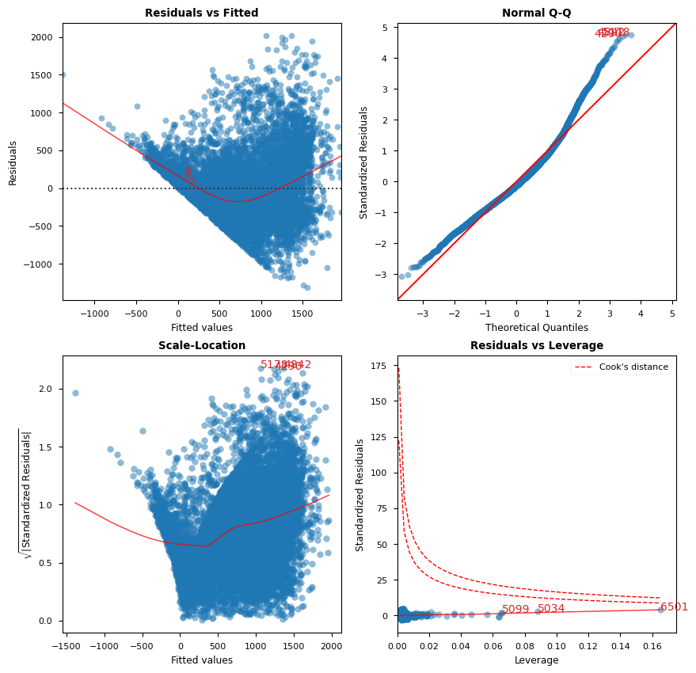

```
                 Features  VIF Factor
0               Intercept        0.00
4   Holiday[T.No Holiday]        1.05
27               Rainfall        1.05
28               Snowfall        1.10
22                   Hour        1.16
25             wind_speed        1.20
26        Solar_radiation        1.57
24               Humidity        1.70
16     Weekday[T.Tuesday]        1.72
21      Weekday[T.Sunday]        1.72
17   Weekday[T.Wednesday]        1.72
18    Weekday[T.Thursday]        1.72
20    Weekday[T.Saturday]        1.73
19      Weekday[T.Fryday]        1.73
```

[output cut: 16 more lines]

```python
# Fig and ax can be used to modify axes or plot properties after the fact.
cls = Linear_Reg_Diagnostic(res2)
fig, ax = cls()

#fig.savefig('../../docs/source/_static/images/linear_regression_diagnostics_plots.png')
```

## Revisando Variables

```python
# Usando solo la variable temperatura

mod_temperatura = smf.ols(formula='Rented_Bike_Count ~  Temperature' ,data=bikedata_final)
res_temperatura = mod_temperatura.fit()
print(res_temperatura.summary())
```

```
                            OLS Regression Results
==============================================================================
Dep. Variable:      Rented_Bike_Count   R-squared:                       0.266
Model:                            OLS   Adj. R-squared:                  0.266
Method:                 Least Squares   F-statistic:                     3175.
Date:                Mon, 17 Oct 2022   Prob (F-statistic):               0.00
Time:                        22:13:40   Log-Likelihood:                -67708.
No. Observations:                8760   AIC:                         1.354e+05
Df Residuals:                    8758   BIC:                         1.354e+05
Df Model:                           1
Covariance Type:            nonrobust
===============================================================================
                  coef    std err          t      P>|t|      [0.025      0.975]
-------------------------------------------------------------------------------
Intercept     409.3954      8.266     49.525      0.000     393.191     425.600
Temperature     2.7867      0.049     56.344      0.000       2.690       2.884
==============================================================================
Omnibus:                     1302.651   Durbin-Watson:                   0.377
Prob(Omnibus):                  0.000   Jarque-Bera (JB):             2239.593
Skew:                           0.981   Prob(JB):                         0.00
Kurtosis:                       4.512   Cond. No.                         235.
==============================================================================

Notes:
[1] Standard Errors assume that the covariance matrix of the errors is correctly specified.
```

```python
# Extraemos los parámetros del modelo para luego hacemos un gráfico de los datos y el ajuste

params_temperatura= res_temperatura.params
print(params_temperatura)
```

```
Intercept      409.395381
Temperature      2.786727
dtype: float64
```

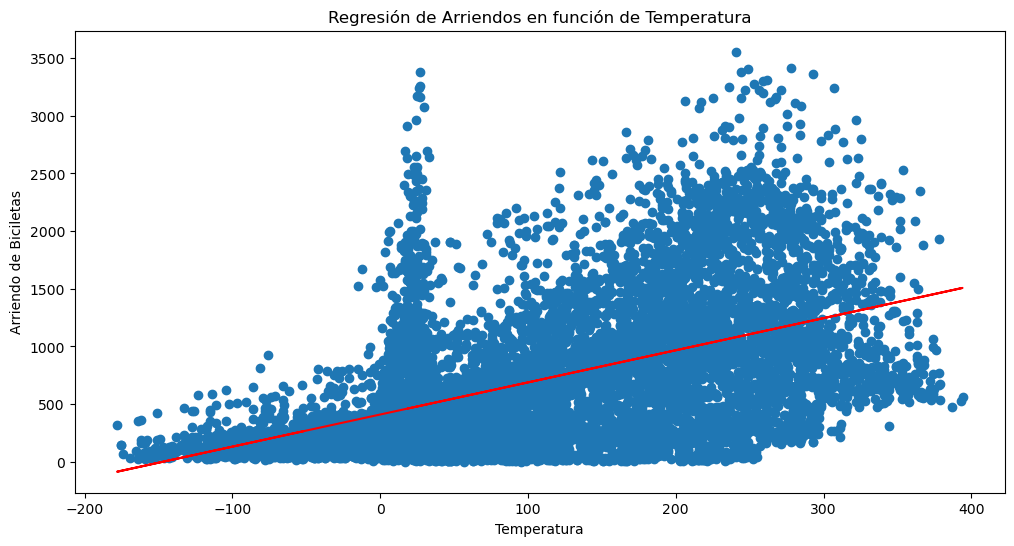

```python
import matplotlib.pyplot as plt
import numpy as np
fig, ax = plt.subplots(figsize=(12, 6))

ax.plot(bikedata_final['Temperature'], bikedata_final['Rented_Bike_Count'], "o", label="Data")
ax.plot(bikedata_final['Temperature'], params_temperatura['Intercept']+params_temperatura['Temperature']*bikedata_final['Temperature']  , "r-", label="Predicted")
ax.set_ylabel("Arriendo de Biciletas")
ax.set_xlabel("Temperatura")
ax.set_title("Regresión de Arriendos en función de Temperatura")
```

### Chequeo del modelo

```python
name = ["t value", "p value"]
test = sms.linear_harvey_collier(res_temperatura)
lzip(name, test)
```

```
[('t value', 7.7876054959367105), ('p value', 7.607627768700598e-15)]
```

```python
# Estimar normalidad de los residuos:
# Jarque_Bera test
name = ["Jarque-Bera", "Chi^2 two-tail prob.", "Skew", "Kurtosis"]
test = sms.jarque_bera(res_temperatura.resid)
lzip(name, test)
```

```
[('Jarque-Bera', 2239.5929901965546),
 ('Chi^2 two-tail prob.', 0.0),
 ('Skew', 0.9809262118362768),
 ('Kurtosis', 4.51228511655312)]
```

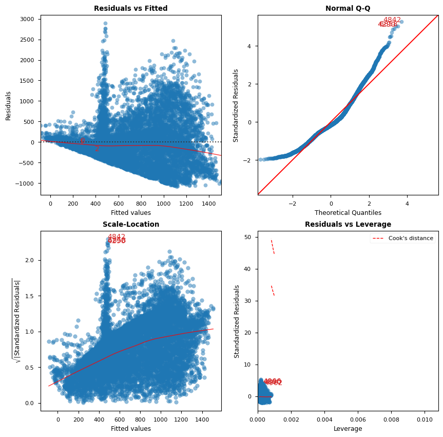

```
      Features  VIF Factor
1  Temperature        1.00
0    Intercept        1.98
```

```python
cls_temperatura = Linear_Reg_Diagnostic(res_temperatura)
fig, ax = cls_temperatura()
```

### LLUVIA

```python
# Usando solo la variable Lluvia

mod_lluvia = smf.ols(formula='Rented_Bike_Count ~  Rainfall' ,data=bikedata_final)
res_lluvia = mod_lluvia.fit()
print(res_lluvia.summary())
```

```
                            OLS Regression Results
==============================================================================
Dep. Variable:      Rented_Bike_Count   R-squared:                       0.012
Model:                            OLS   Adj. R-squared:                  0.011
Method:                 Least Squares   F-statistic:                     102.3
Date:                Mon, 17 Oct 2022   Prob (F-statistic):           6.54e-24
Time:                        22:13:43   Log-Likelihood:                -69012.
No. Observations:                8760   AIC:                         1.380e+05
Df Residuals:                    8758   BIC:                         1.380e+05
Df Model:                           1
Covariance Type:            nonrobust
==============================================================================
                 coef    std err          t      P>|t|      [0.025      0.975]
------------------------------------------------------------------------------
Intercept    744.5912      6.866    108.441      0.000     731.132     758.051
Rainfall      -8.7798      0.868    -10.113      0.000     -10.482      -7.078
==============================================================================
Omnibus:                     1360.945   Durbin-Watson:                   0.215
Prob(Omnibus):                  0.000   Jarque-Bera (JB):             2084.504
Skew:                           1.127   Prob(JB):                         0.00
Kurtosis:                       3.793   Cond. No.                         7.96
==============================================================================

Notes:
[1] Standard Errors assume that the covariance matrix of the errors is correctly specified.
```

```python
# Extraemos los parámetros del modelo para luego hacemos un gráfico de los datos y el ajuste

params_lluvia= res_lluvia.params
print(params_lluvia)
```

```
Intercept    744.591187
Rainfall      -8.779804
dtype: float64
```

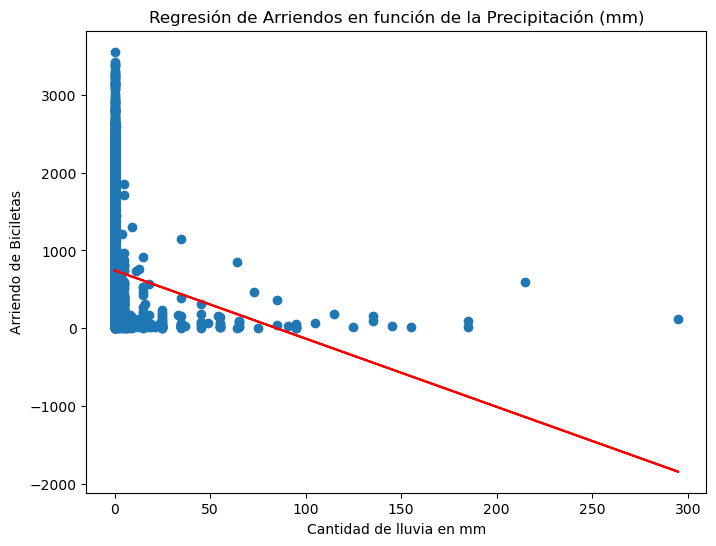

```python
fig, ax = plt.subplots(figsize=(8, 6))

ax.plot(bikedata_final['Rainfall'], bikedata_final['Rented_Bike_Count'], "o", label="Data")
ax.plot(bikedata_final['Rainfall'], params_lluvia['Intercept']+params_lluvia['Rainfall']*bikedata_final['Rainfall']  , "r-", label="Predicted")
ax.set_ylabel("Arriendo de Biciletas")
ax.set_xlabel("Cantidad de lluvia en mm")
ax.set_title("Regresión de Arriendos en función de la Precipitación (mm)")
```